# ChameleoK: K-anonymity in R

Julian Sengewald

2025-05-19

[figure not shown]

logo

# A consice introduction to privacy

## Understanding k-anonymity

K-anonymity is a privacy model designed to protect against identification of individuals in published data. The key concepts are:

- **Data Classification**: Data attributes are categorized as direct identifiers (DI), quasi-identifiers (QID), privacy-protected attributes (PA), and non-privacy-protected attributes (NP).
- **Direct Identifiers**: These uniquely identify individuals (e.g., names) and are typically removed entirely or should be at least replaced by non-meaningfull ids.
- **Quasi-identifiers (quid)**: These identifiers can identify individuals only when combined with other attributes (e.g., age, gender, zip code). Quais-identifier as a collection of attributes identifies individuals. The attack works by singeling out individuals with public available or observable information. For example, your neighbor might have a good guess about your age, knows your gender and has the same zip code. With this knowledge a individual can be identified in a dataset. Sometimes it is also enough knowing that a person has participated in a survey e.g. when zip code is not included in the disseminated data. Removing these attributes would result in a loss of valuable information.

The K-anonymity privacy model trades-off some of the forementioned loss of information about quasi-identifiers with a reduction of the risk of re-identification. The idea is to modify quid so that each combination of quasi-identifiers appears at least k times in the dataset, forming “equivalence classes” of at least k records. This is achieved through generalization (making data values less specific) until the k-anonymity requirement is met. As k increases, the identification risk decreases proportionally to 1/k. So higher values of k provide stronger privacy protection but also lead to more data loss.

Important: While k-anonymity protects against identity disclosure, it may not fully protect against attribute disclosure, as sensitive information might still be inferred within equivalence classes. More advanced models like t-closeness and differential privacy address some of these limitations for comprehensive privacy protection. So k-anonymity is not the end of the story. But it still usefull for many applications.

## Quick Guide!

The package implements the core datafly algorithm, which is one method for anonymizing data. The algorithm works by generalizing the data in such a way that it becomes k-anonymous, meaning that each record in the dataset is indistinguishable from at least k-1 other records. It is a privacy-preserving technique that helps protect against re-identification of individuals in the dataset.

[output not shown]

```r
library(ChameleoK)
library(dplyr)
# ---
# Adult dataset
# ---
adult <- read.table('https://archive.ics.uci.edu/ml/machine-learning-databases/adult/adult.data',
                    sep = ',', fill = F, strip.white = T)
colnames(adult) <- c('age', 'workclass', 'fnlwgt', 'educatoin',
                     'educatoin_num', 'marital_status', 'occupation', 'relationship', 'race', 'sex',
                     'capital_gain', 'capital_loss', 'hours_per_week', 'nativecountry', 'income')
nrow(adult) # 48842
```

```
## [1] 32561
```

```r
ncol(adult) # 15
```

```
## [1] 15
```

Investigate the dataset and its attributes. The dataset contains 15 attributes, including both quasi-identifiers and sensitive attributes.

Glancing at the data, we can see that the dataset is not k-anonymous. For example, the combination of age and sex at the moment uniquely identifies some individuals (e.g. single person can be identified). The function `isKAnonymous` checks if the dataset is k-anonymous for a set of quid, which is convenient if there are many of them.

```r
table(adult$age, adult$sex) %>% tail() # clearly not k-anonymous
```

```
##
##      Female Male
##   84      4    6
##   85      1    2
##   86      1    0
##   87      0    1
##   88      1    2
##   90     14   29
```

```r
isKAnonymous(data = adult, quid = c("sex", "age", "race"), k=50) # package function
```

```
## The data is not 50-anonymouse. The minimum size of a equivalence class is 1
```

```
## [1] FALSE
```

Generalization is the process of replacing specific values with more general ones. For example, instead of using exact ages, we can group ages into ranges (e.g., 20-30, 30-40). With categorical attributes, one can proceed similarly by replacing specific values with broader categories (e.g., “California” can be replaced with “USA”).

The hierarchy can be visualized using the `plot_hierarchy` function.

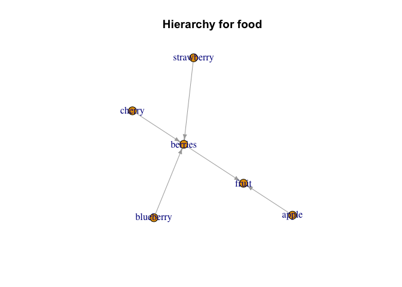

```r
#---
# Example of a hierarchy
#---
food <- list()
food <- add_gen("cherry", "berries", food)
food <- add_gen("blueberry", "berries", food)
food <- add_gen("strawberry", "berries", food)
food <- add_gen("apple", "fruit", food)
food <- add_gen("berries", "fruit", food)
hierarchy <- list()
hierarchy[["food"]] <- food
plot_hierarchy(hierarchy, "food")
```

Currently, the package supports two types of creating hierarchies for the quasi-identifiers (quid) in the dataset: import from a CSV file or manually creating the hierarchy (as above).

For the csv import, the hierachy has to be specified - obviously - in a CSV file outside of R with two columns: `parent` and `child`. The `parent` column contains the parent category, and the `child` column contains the child category. Skip connection are also possible if one generalization level is not enough to reach k-anonymity (see examples).

[figure not shown]

```r
# ---
# Importing the hierarchy from a csv file
# ---
taxonomy_adult <- read_hierachy_from_csv(path = "./hierachy/adult/")
par(mfrow=c(1,2))
plot_hierarchy(taxonomy_adult, "nativecountry")
plot_hierarchy(taxonomy_adult, "age")
```

The package implements the core datafly algorithm, which is one feasible method for anonymizing data.

The syntax is as follows:

```r
train_index <- sample(1:nrow(adult), nrow(adult)*0.8)
train_adult <- adult[train_index,]
test_adult <- adult[-train_index,]
ano_data <- core_datafly(data=train_adult, test_data = test_adult,  quid=c("sex", "age", "race"), k=50, taxonomy=taxonomy_adult)

table(ano_data$training$sex, ano_data$training$age)
```

```
##
##          17-28 29-48 49-60 61-90    *
##   Female  2959  3828  1198   584    0
##   Male    4169  8970  3030  1296    0
##   *          0     0     0     0    0
```

```r
isKAnonymous(data = ano_data$training, quid = c("sex", "age", "race"), k=50)
```

```
## The data is 50-anonymouse for the quid: sex and age and race
```

```
## [1] TRUE
```

The * means that some quids are in the combination so unique that those categories of the attribute needs to be excluded from the further anonymization process.

# References

Sweeney, L. (2002). k-anonymity: A model for protecting privacy. International journal of uncertainty, fuzziness and knowledge-based systems, 10(05), 557-570. Sweeney, L. (1998). Datafly: A system for providing anonymity in medical data. Database Security XI: Status and Prospects, 356-381.